# Penguin Size Comparisons

Lindsay Hafen

11/15/2020

# Part 1. T-tests

-Compare means between 2 groups - enough evidence to make us think that the data is drawn from populaitons with different means? - Mass comparison between male and female chinstrap penguins

- Could filter male and females to make histograms, but ggplot can do that for us with the facet capability
- QQ plot compare our sample to data if it were perfectly drawn from a population with perfectly normal distribution (closer to straight line = closer to normal dist)

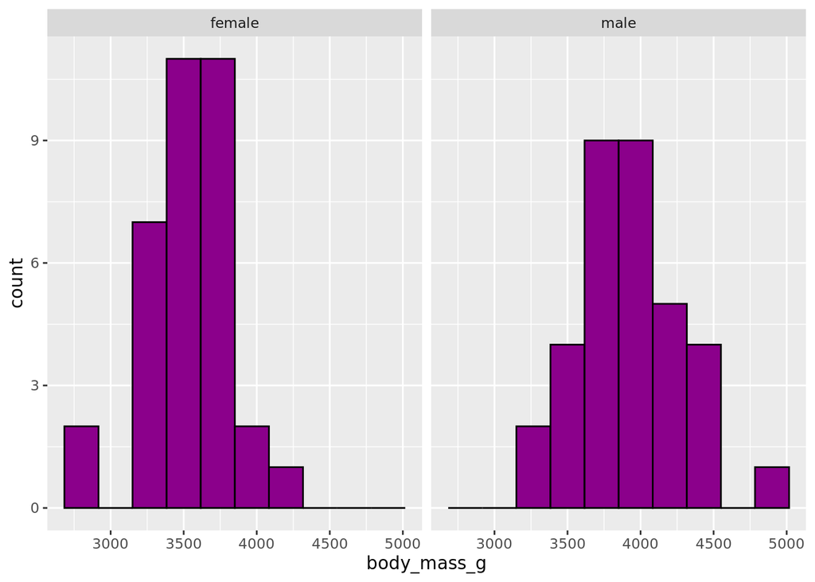

```r
chinstraps <- penguins %>%
  filter(species == "Chinstrap")

# Histograms
ggplot(chinstraps, aes(x = body_mass_g)) +
  geom_histogram(bins = 10, fill = "darkmagenta", color = "black") +
  facet_wrap(~ sex)
```

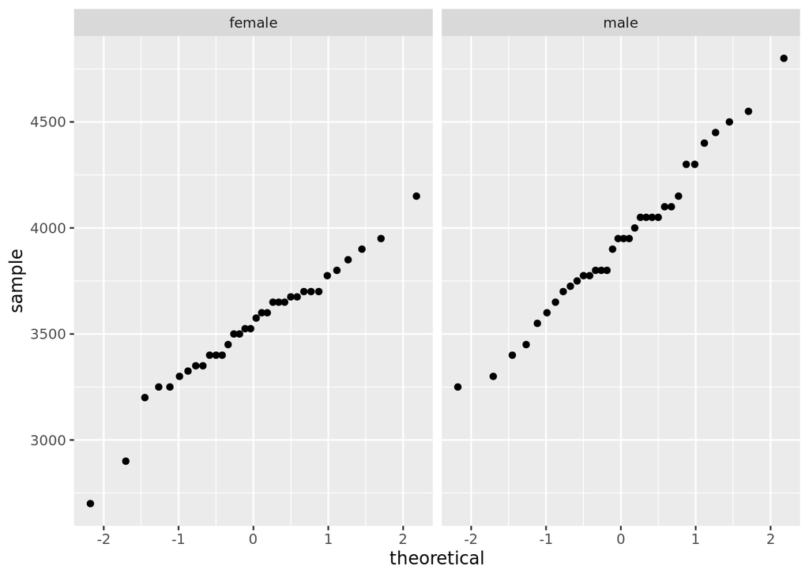

```r
## QQ plot:
ggplot(chinstraps, aes(sample = body_mass_g)) +
  geom_qq() +
  facet_wrap(~ sex)
```

```r
# Descriptive statistics
chinstraps %>%
  group_by(sex) %>%
  summarize(mean_mass = mean(body_mass_g),
            median_mass = median(body_mass_g),
            sd_mass = sd(body_mass_g),
            sample_size = n())
```

```
## # A tibble: 2 x 5
##   sex    mean_mass median_mass sd_mass sample_size
##   <fct>      <dbl>       <dbl>   <dbl>       <int>
## 1 female     3527.        3550    285.          34
## 2 male       3939.        3950    362.          34
```

## Get vectors of body_mass_g for female and male chinstrap penguins seperately

pull will pull out values from just what we specify

```r
chinstraps_f <- chinstraps %>%
  filter(sex == "female") %>%
  pull(body_mass_g)

chinstraps_m <- chinstraps %>%
  filter(sex == "male") %>%
  pull(body_mass_g)
```

## Run t-tests in a couple of ways

1. Is there a *significant* difference in body mass between male and female chinstrap penguins -Welch’s (Not assumeing equal variance)

```r
chinstrap_ttest <- t.test(chinstraps_f, chinstraps_m)
chinstrap_ttest
```

```
##
##  Welch Two Sample t-test
##
## data:  chinstraps_f and chinstraps_m
## t = -5.2077, df = 62.575, p-value = 2.264e-06
## alternative hypothesis: true difference in means is not equal to 0
## 95 percent confidence interval:
##  -569.7903 -253.7391
## sample estimates:
## mean of x mean of y
##  3527.206  3938.971
```

```r
# But what about context: actual difference (how much larger are males than females?), effect size?
cohen.d(chinstraps_m, chinstraps_f)
```

```
##
## Cohen's d
##
## d estimate: 1.263061 (large)
## 95 percent confidence interval:
##     lower     upper
## 0.7327341 1.7933879
```

```r
# Codealong key has a tutorial of how to use broom function to include data frame for test outcomes in the knitted doc (?)
```

### Are male chinstrap penguins significantly larger (body mass) than female chinstrap penguins

- One sided test - only interested in one tail of the mean distribution) (What is the prob that I could have gotten a mean difference this large or larger)

```r
t.test(chinstraps_m, chinstraps_f, alternative = "greater") #greater or less depends on the order of vectors in the t.test function = in this case males>females
```

```
##
##  Welch Two Sample t-test
##
## data:  chinstraps_m and chinstraps_f
## t = 5.2077, df = 62.575, p-value = 1.132e-06
## alternative hypothesis: true difference in means is greater than 0
## 95 percent confidence interval:
##  279.7552      Inf
## sample estimates:
## mean of x mean of y
##  3938.971  3527.206
```

# One way ANOVA and beeswarm graph mean w/ error bars shown

- One way = single factor
- Three or more groups
- Mean flipper length between 3 species, only female

### Table of counts by species and sex

- Could group_by(species, sex) %>% summarize(n()) OR
- Penguin counts:

```r
penguin_counts <- penguins %>%
  count(species, sex)

penguin_counts
```

```
## # A tibble: 8 x 3
##   species   sex        n
##   <fct>     <fct>  <int>
## 1 Adelie    female    73
## 2 Adelie    male      73
## 3 Adelie    <NA>       6
## 4 Chinstrap female    34
## 5 Chinstrap male      34
## 6 Gentoo    female    58
## 7 Gentoo    male      61
## 8 Gentoo    <NA>       5
```

Create a subset of only female penguins:

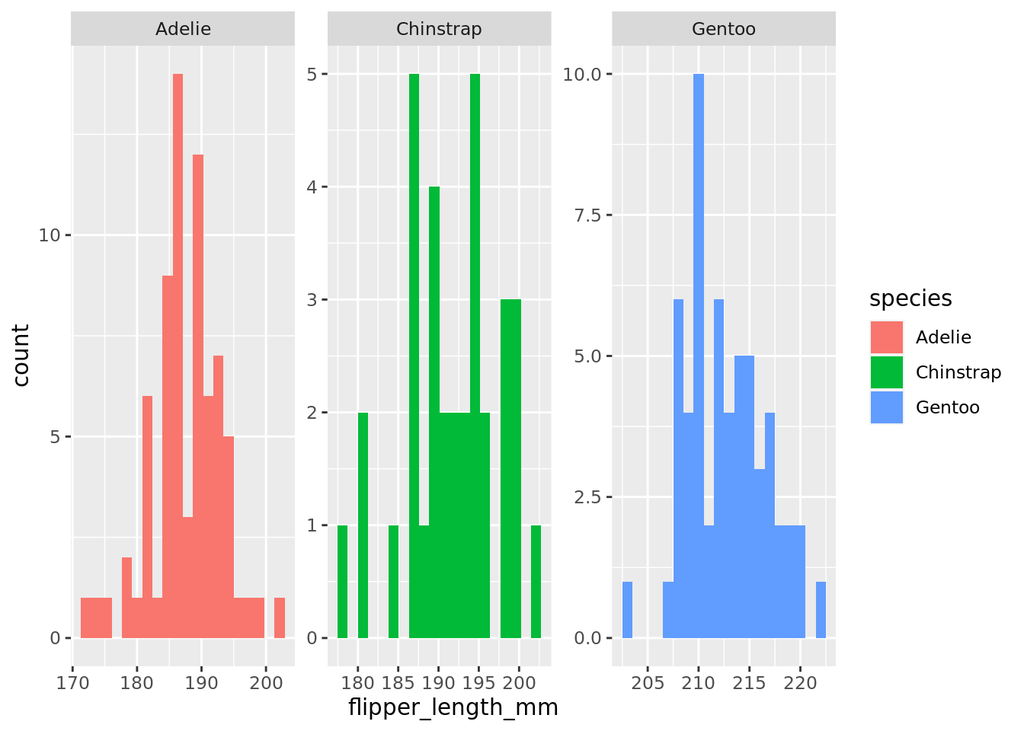

```r
penguins_f <- penguins %>%
  filter(sex == "female")

ggplot(data = penguins_f, aes(x = flipper_length_mm)) +
  geom_histogram(bins = 20, aes(fill = species)) + # One option using fill to separate
  facet_wrap(~ species, scales = "free") # Default scales ea. the same, if want ea pannel to have different x and y axis limits, then scales = "free"
```

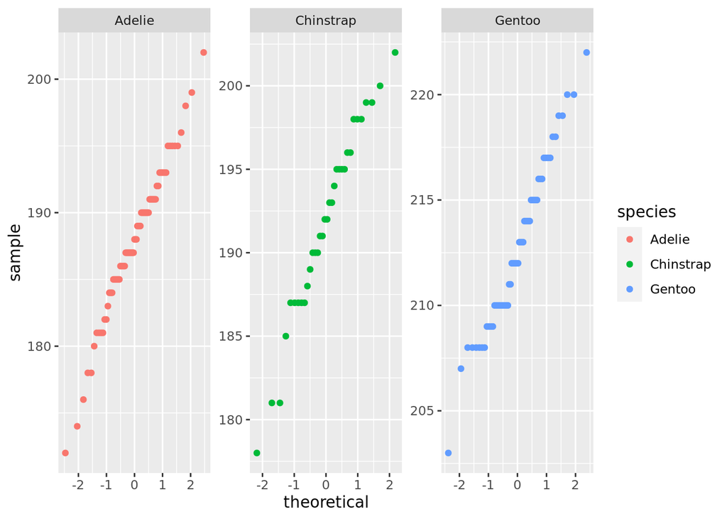

```r
ggplot(data = penguins_f, aes(sample = flipper_length_mm)) +
  geom_qq(aes(color = species)) +
  facet_wrap(~ species, scales = "free") # similar code to above = can copy paste and change
```

### Summary stats, check for equal variances here too

-Starting from penguins_f, create a summary table that groups by species and returns: -mean of flipper length -sd of flipper_length_mm -sample size -variance ‘var’ -standard error = sd/sqrt(n)

- Guideline: if your largest var for a group is less than 4x greater than smallest var for a group, then var is close enough to perform ANOVA

```r
penguins_f_summary <- penguins_f %>%
  group_by(species) %>%
  summarize(mean_flipper_length = mean(flipper_length_mm),
            sd_flipper_length = sd(flipper_length_mm),
            sample_size = n(),
            variance = var(flipper_length_mm),
            standard_error = sd(flipper_length_mm)/sqrt(n()),
            var_flipper_length = var(flipper_length_mm))
penguins_f_summary
```

```
## # A tibble: 3 x 7
##   species mean_flipper_le… sd_flipper_leng… sample_size variance standard_error
##   <fct>              <dbl>            <dbl>       <int>    <dbl>          <dbl>
## 1 Adelie              188.             5.60          73     31.3          0.655
## 2 Chinst…             192.             5.75          34     33.1          0.987
## 3 Gentoo              213.             3.90          58     15.2          0.512
## # … with 1 more variable: var_flipper_length <dbl>
```

```r
leveneTest(flipper_length_mm ~ species, data = penguins_f)
```

```
## Levene's Test for Homogeneity of Variance (center = median)
##        Df F value  Pr(>F)
## group   2  2.9012 0.05782 .
##       162
## ---
## Signif. codes:  0 '***' 0.001 '**' 0.01 '*' 0.05 '.' 0.1 ' ' 1
```

Lavene’s - if n() is great enough, you *will* get a significant difference no matter what, so be careful to look and think and check guideline - 0.05782 Pr number is greater than our usual significance value of .05, so we will retain the null that the variance is equal

## How to make a Beeswarm plot

- Show some summary statistics
- Mean =/- 1 sd
- Generic plot is better than our modificaitons, modifications for example
- Add geom points to layer graphs on top of each other.

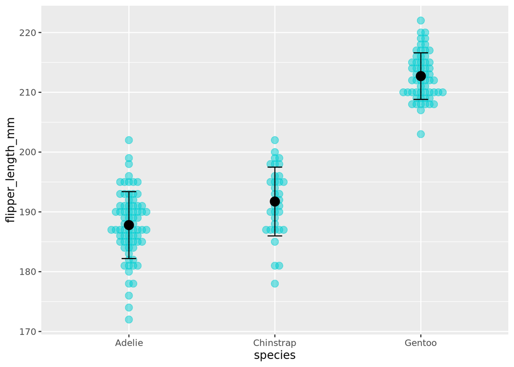

```r
ggplot() +
  geom_beeswarm(data = penguins_f,
                aes(x = species, y = flipper_length_mm),
                color = "darkturquoise",
                size = 3,
                alpha = 0.5) +
  geom_point(data = penguins_f_summary, aes(x = species, y = mean_flipper_length),
             size = 4) +
  geom_errorbar(data = penguins_f_summary,
                aes(x = species,
                    ymax = mean_flipper_length + sd_flipper_length,
                    ymin = mean_flipper_length - sd_flipper_length),
                width = 0.1)
```

### One-way ANOVA

- Start by aov -> runs type 1 ANOVA (If everything is matched (balanced design, equal sample size etc, then it’s the same as a type III anova)) – F statistic is the ratio of the between group variance divided by the within group variance (Variance = sum of squares)
- 2e-16*** is the smallest number that R will display (Super small propbability that the populations are all from a population that has the same mean)

```r
penguin_aov <- aov(flipper_length_mm ~ species, data = penguins_f)
summary(penguin_aov)
```

```
##              Df Sum Sq Mean Sq F value Pr(>F)
## species       2  21416   10708   411.8 <2e-16 ***
## Residuals   162   4213      26
## ---
## Signif. codes:  0 '***' 0.001 '**' 0.01 '*' 0.05 '.' 0.1 ' ' 1
```

```r
TukeyHSD(penguin_aov)
```

```
##   Tukey multiple comparisons of means
##     95% family-wise confidence level
##
## Fit: aov(formula = flipper_length_mm ~ species, data = penguins_f)
##
## $species
##                       diff       lwr       upr     p adj
## Chinstrap-Adelie  3.940774  1.436275  6.445272 0.0007922
## Gentoo-Adelie    24.912376 22.790647 27.034105 0.0000000
## Gentoo-Chinstrap 20.971602 18.366227 23.576977 0.0000000
```

- All of the pairwise adjusted values from Tukey’s are below .05, so the post-hoc test tells us that there is a significant difference between each combination of the groups.

#### If you have very different sample sizes, unbalanced designs, differences between groups and distributions etc then do a type III ANOVA with the car package:

-lm stands for linear model

```r
penguin_lm <- lm(flipper_length_mm ~ species, data = penguins_f)
penguin_aov_t3 <- Anova(penguin_lm, type = "III")
penguin_aov_t3
```

```
## Anova Table (Type III tests)
##
## Response: flipper_length_mm
##              Sum Sq  Df  F value    Pr(>F)
## (Intercept) 2574475   1 99005.28 < 2.2e-16 ***
## species       21416   2   411.79 < 2.2e-16 ***
## Residuals      4213 162
## ---
## Signif. codes:  0 '***' 0.001 '**' 0.01 '*' 0.05 '.' 0.1 ' ' 1
```

- Most of the time, the aov and the type III are very similar (Unless egregiously unbalanced) (F value of species is very similar to the one above as well) (If perfectly balanced, then type I, II, and III will give you the exact same value)